# PDE Calculation Verification

**This notebook is part of the FDA SimEval toolbox, https://github.com/OSEL-DAM/SimEval**

# 1. Introduction

Calculation verification, also known as solution verification, is defined in FDA, 2023 as *"the process of determining the solution accuracy of a calculation"*. In contrast to code verification, calculation verification is focused on estimating numerical error for a specific simulation. As discussed in FDA, 2023, calculation verification can be performed for validation simulations, i.e., simulations whose results will be compared to experimental/clinical data, or context of use simulations, i.e., a simulations performed as part of a simution study to address the question of interest.

Partial differential equations (PDEs) arise when solving governing differential equations in space and time and/or in multiple spatial dimensions. Since numerical errors for PDEs are typically dominated by discretization errors (as opposed to numerical solver (iterative) error or round-off error), calculation verification for PDEs typically involves running simulations using different spatial and temporal discretizations. This notebook is focused on time-independent PDEs and spatial discretization error.

There are two common approaches to calculation verification. One approach is to perform a convergence study and confirm that there is little difference between the solutions using the different meshes. However, this approch often involves arbitrarily chosen acceptance criteria (for example, 1% or 5% difference between meshes), and does not guarantee the true solution is within that percentage of the final numerical estimate, because the convergence may not yet be in the assympototic range or other factors.

A more rigorous approach is to compute the quantity of interest using three or more mesh resolutions and calculate the observed order of convergence, which can be compared to the theoretical order of convergence (if known). Subsequently, Richardson extrapolation can be used to compute a higher order estimate of the true solution. In addition, the grid convergence index (GCI), which provides a measure of the discretization uncertainty in the numerical solution, can be calculated. These three metrics provide important quantitative information about the accuracy of the numerical solution. For a detailed introduction to these concepts see Roache, 2009 and Oberkampf & Roy, 2025.

The `calcverif` module in the SimEval Toolbox provides functions for computing these metrics. This notebook demonstrates how to use the module.

## 1.1. Preliminary steps

The `calcverif` module processes mesh convergence results. A possible workflow for generating mesh convergence results is:

1. **Identify worst case parameters:** This step applies if it is not possible, or too computationally expensive, to perform mesh convergence studies for all the simulations of interest (i.e., all the validation simulations or all the COU simulations). If so, a sensible approach is to identify worst-case parameter settings, for example involving the greatest Reynold's number in computational fluid dynamics, the greatest strains in solid mechanics, or the most complex physiological response in cardiac electrophysiology.
2. **Perform mesh refinement and simulations:** Generally, at least three meshes are needed to compute the metrics.
   - For structured meshes, the meshes are characterized using a spatial stepsize $h$, for example the element size in 1D, or edge-length for structured grids comprised of 2D rectangular elements or 3D cuboid elements.
   - For unstructured meshes, the grid refinement needs to be uniform and consistent to be apply the below analysis algorithm. Uniform means that the local element length scale change is uniform across the meshes (which precludes, for example, local mesh refinement), and consistent means mesh quality does not deteriorate with refinement; see Oberkampf & Roy, 2025.

The mesh ratio, $r$, is defined as the ratio between successive $h$ values for structured meshes, or as $r = (n_f/n_c)^{1/d}$ for unstructured meshes that have been uniformly refined, where $n_f$ and $n_c$ are the number of elements in the finer and coarser mesh respectively and $d$ is the spatial dimension. $r$ does not have to be constant across all the meshes. When computationally feasible, typically $r=2$ would be chosen. When that is computationally challenging, ASME V&V20 (ASME, 2009) recommends that $r$ be at least 1.3, and highly recommends avoiding different $r$ values in different directions (e.g., $r_x=1.3$ and $r_y=1.6$).

Once the quantity of interest has been computed on a series of meshes, the analysis algorithm can be applied.

## 1.2. Analysis algorithm

The `calcverif` module implements the following algorithm, which is based on recommendations and workflows in Roache, 2009 and Oberkampf & Roy, 2025.

First consider the **structured mesh case**. In this case the meshes can be characterized by a spatial stepsize $h$. Let $h_1, h_2, \ldots, h_N$ denote the spatial resolutions for the $N$ meshes, from **finest to coarest**, so $h_1 < h_2 < \ldots < h_N$.

For **unstructured meshes that have been uniformly refined**, assume a mesh refinement study has been performed with $n_1 > n_2 > \ldots > n_N$ elements in each mesh, again going from finest to coarest. We can calculate an effective $h$ value for each mesh, $h_i = (n_1/n_i)^{1/d}$, where $d$ is the spatial dimension. In this way $h_1=1$ and the following $h$ values increase at the appropriate ratios. For **unstructured meshes that have not been uniformly refined**, the metrics cannot be computed. For a method to assess the uniformity of the mesh refinement, see Oberkampf & Roy, 2025.

Assuming a scalar quantity of interest $q$, let $q_1, q_2, \ldots, q_N$ be the corresponding numerical solutions of $q$ on these meshes. The metrics are computed as follows:

**$N=3$ case:**

1. Assess the convergence behavior of the three $q_i$:
   - Monotonic convergence if $|q_1 - q_2|<|q_2-q_3|$ and $(q_1 - q_2)$ & $(q_2 - q_3)$ have the same sign
   - Oscillatory convergence if $|q_1 - q_2|<|q_2-q_3|$ but $(q_1 - q_2)$ & $(q_2 - q_3)$ have different signs
   - Divergence if $|q_1 - q_2|\ge |q_2-q_3|$
2. If divergence:
   - Cannot continue. User is asked to repeat with finer meshes (in case, for example, divergence was due to complicated physics such as shocks or contact that were not resolved properly in the current meshes) and/or investigate if there is an error in the solver.
3. If oscillatory convergence:
   - User is asked to perform one or more simulations (holding $r \approx$ constant) and go to the $N>3$ case below
4. If monotonic convergence (based on methods described in Roache, 2009 and Oberkampf & Roy, 2025):
   - Compute the unconstrained observed order of convergence (OOC) $p$. If $r_{21}=h_2/h_1$ is not equal $r_{32}=h_3/h_2$, $p$ is found by solving the transcendental equation: \begin{equation} r_{21}^{p}\left(\frac{r_{32}^p-1}{r_{21}^p-1}\right) = \frac{q_3-q_2}{q_2-q_1} \end{equation} When $r_{21}=r_{32}=r$, this simplifies to $p = \ln\left(\frac{q_3-q_2}{q_2-q_1}\right)/\ln(r)$.
   - Compute the constrained order of convergence $p^*$ and GCI safety factor $F_s$, using $p$ and the formal order of convergence $p_f$ (if provided): \begin{equation} p^* = \left\{ \begin{aligned} &\max(\tfrac{1}{2}, p) && F_s = 3 && \text{if no $p_f$ provided,} \\ &p_f && F_s = 1.25 && \text{if } |p - p_f| \le 0.1\,p_f, \\ &\min(\max(\tfrac{1}{2}, p), p_f) && F_s = 3 && \text{if } |p - p_f| > 0.1\,p_f \end{aligned} \right. \end{equation}
   - Compute the Richardson extrapolated estimate and GCI  
     \begin{align} q_\textrm{RE} &= q_1 + \frac{q_1 - q_2}{r_{21}^{p^*} - 1} \\ \textrm{GCI} &= \frac{F_s}{(r_{21})^{p^*}-1}|q_2-q_1| \end{align} Note that by default GCI is not normalized by $|q_1|$ as often stated in the literature. Therefore, it is important to be aware that by default **the GCI output will in the same units as the QOI, not a relative GCI**. However, the module provides the option to compute relative GCI, $ \frac{F_s}{(r_{21})^{p^*}-1}\frac{|q_2-q_1|}{|q_1|}$ if preferred.
5. The unconstrained OOC $p$, Richardson extrapolated estimate $q_{\textrm{RE}}$ and GCI are returned to the user.

**$N>3$ case:**

1. Assess the convergence behavior of the first triplet $(h_1, h_2, h_3)$, $(q_1, q_2, q_3)$, i.e., using the three finest meshes.
2. If divergence for first triplet:
   - Cannot continue. User is asked to repeat with finer meshes and/or investigate if there is an error in the solver.
3. If oscillatory convergence for first triplet:
   - Use the least squares calculation verification method (Roache, 2009,Oberkampf & Roy, 2025) to compute the OOC, $q_\textrm{RE}$ and GCI, using all $N$ values. This involves minimizing the function \begin{equation} S(q,\hat{p},\alpha) = \left(\sum_{i=1}^{N} \left(q_i - (q + \alpha h_i^{\hat{p}})\right)^2\right)^{\frac{1}{2}} \end{equation} to obtain $q_{\textrm{RE}}$ and $p$, and then computing GCI as above.
4. If monotonic convergence for first triplet:
   - Compute OOC, $q_\textrm{RE}$ and GCI using the methods cited for the $N=3$ case above using the first triplet.
   - Also analyze each successive triplet, computing OOC, $q_\textrm{RE}$ and GCI for each until reaching a triplet for which the $q_i$ are not monotonically converging. These 'intermediate' values of the metrics are provided to the user so that they can track the convergence of these quantities.

Note: if the QOI is not a scalar, the above algorithm can be applied pointwise. This would require repeated calls to the `analyze` function discussed below. A key step is to ensure that the quantities of interest are collocated on the coarse grid points.

Note that oscillatory convergence is treated differently to ASME V&V20 (ASME, 2009). The method defined in Section 2-4.1 of ASME V&V20 assumes $N=3$ and provides a result whether the convergence is monotonic or oscillatory. However, in our algorithm no solution is provided if $N=3$ and convergence is oscillatory. The user is prompted to provide a fourth data point. This choice is discussed in the supporting publication for this toolbox.

# 2. Examples

Next we demonstrate how to use the `calcverif` module. This module uses a class to organize its functionality. In Python, classes allow the bundling of data and methods (functions) together. First, import the class `CalculationVerificationTool` from `calcverif`, which is in the `src` folder.

```python
import os
import sys
base_dir = os.getcwd()
src_path = os.path.abspath(os.path.join(base_dir, '..', 'src'))
sys.path.insert(0, src_path)

from calcverif import CalculationVerificationTool
```

Next, we need to create an instance of ('instantiate') the class, to use its methods and properties

```python
# create a new instance of the class
calcverif_tool = CalculationVerificationTool()
```

The class `CalculationVerificationTool` provides a range of methods (functions) that the user can call. The full list is provided below.

```python
# show the methods available
methods = [method for method in dir(calcverif_tool) if callable(getattr(calcverif_tool, method)) and not method.startswith('_')]
print(methods)
```

```
['analyze', 'analyze_N3_case', 'analyze_by_n_elems', 'analyze_largeN_mono_case', 'analyze_using_least_squares_method', 'plot']
```

Users can find documentation for these functions by running, for example, `help(calcverif_tool.analyze_using_least_squares_method)`. However, a single 'master' function `analyze()` is available that deals with the logic of the above workflow, except for the unstructured mesh case, for which `analyze_by_n_elems` should be called. Below we show the output of `analyze` under various different cases, using initially synthetic data.

### Number of meshes $N=3$, constant mesh refinement ratio

`analyze` takes in an array of $h$ values, an array of $q$ values, and optionally the theoretical order of convergence, which impacts the computed GCI. Here, we call `analyze` with $N=3$, and a constant mesh refinement ratio $r=2$. The QOI values assume the true solution is 1.5 and second order convergence.

```
Method: standard method, as N=3 and monotonically converging
Absolute GCI not relative GCI
Note: OOC 1.9359 < formal order, but within 10% - using formal order for calculating RE and GCI
OOC = 1.9358635332079677, extrapolated soln = 1.4987433333333333, GCI = 0.04234958333333335
```

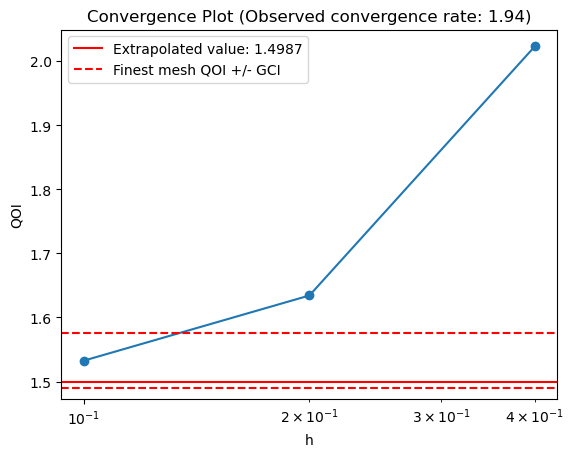

```python
h_values = [0.1, 0.2, 0.4]
qoi_values = [1.532623,1.634262,2.02314]  # qoi = 1.5 + 3.25*h^2 + small noise

# call the analyze method
ooc, re, gci = calcverif_tool.analyze(h_values,qoi_values,formal_order_conv = 2.0)
print(f"OOC = {ooc}, extrapolated soln = {re}, GCI = {gci}")
# plot the results
fig, ax = calcverif_tool.plot()
```

The Richardson extrapolated value is closer to 1.5 than the solution on the final mesh, and the GCI band is quite narrow. Repeating but assuming the theoretical order is 3, so that the observed order is less than the theoretical order, leads to a larger GCI band and a slightly different Richardson extrapolated value (see definitions above for why):

```
Method: standard method, as N=3 and monotonically converging
Absolute GCI not relative GCI
OOC = 1.9358635332079677, extrapolated soln = 1.4966582239041357, GCI = 0.10789432828759332
```

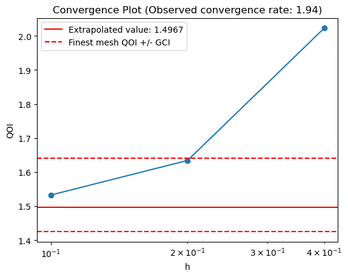

```python
h_values = [0.1, 0.2, 0.4]
qoi_values = [1.532623,1.634262,2.02314]   # qoi = 1.5 + 3.25*h^2 + small noise
ooc, re, gci = calcverif_tool.analyze(h_values,qoi_values,formal_order_conv = 3.0)
print(f"OOC = {ooc}, extrapolated soln = {re}, GCI = {gci}")
fig, ax = calcverif_tool.plot()
```

### Relative GCI

The above used the default option of absolute GCI. Relative GCI can be computed instead by passing an optional parameter into the `CalculationVerificationTool` constructor. Note that relative GCI returned is a dimensionless fraction, not a percentage.

```
Method: standard method, as N=3 and monotonically converging
Relative GCI not absolute GCI
Note: OOC 1.9359 < formal order, but within 10% - using formal order for calculating RE and GCI
OOC = 1.9358635332079677, extrapolated soln = 1.4987433333333333, Relative GCI = 0.027632094346315663
```

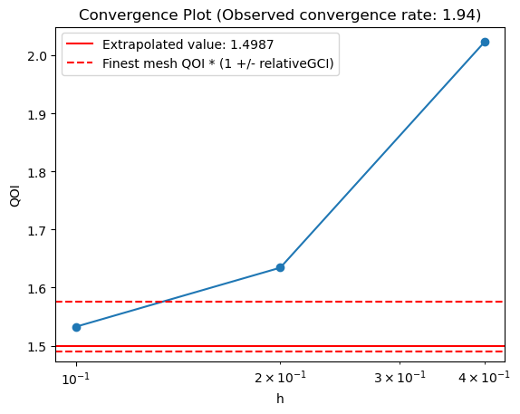

```python
calcverif_tool2 = CalculationVerificationTool(use_absolute_GCI = False)
h_values = [0.1, 0.2, 0.4]
qoi_values = [1.532623,1.634262,2.02314]  # qoi = 1.5 + 3.25*h^2 + small noise

ooc, re, gci = calcverif_tool2.analyze(h_values,qoi_values,formal_order_conv = 2.0)
print(f"OOC = {ooc}, extrapolated soln = {re}, Relative GCI = {gci}")
fig, ax = calcverif_tool2.plot()
```

### Number of meshes $N=3$, non-constant mesh refinement ratio

Now suppose that it is not possible to use a constant refinement ratio. The same interface can be used, but a nonlinear function will be solved under the hood:

```
Method: standard method, as N=3 and monotonically converging
Absolute GCI not relative GCI
Note: OOC 2.0116 >= formal order - using formal order for calculating RE and GCI
OOC = 2.011578657499237, extrapolated soln = 1.500068523809524, GCI = 0.040693095238095243
```

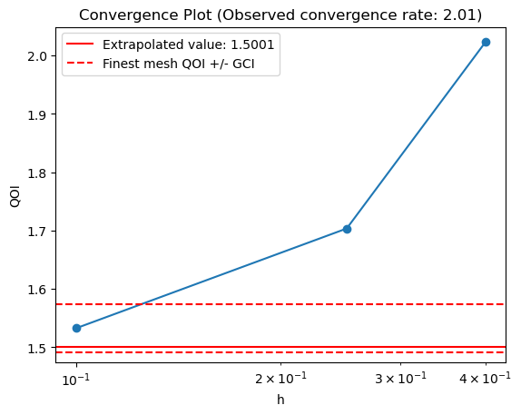

```python
h_values = [0.1, 0.25, 0.4]                # non-constant mesh ratio
qoi_values = [1.532623,1.703534,2.02314]   # qoi = 1.5 + 3.25*h^2 + small noise
ooc, re, gci = calcverif_tool.analyze(h_values,qoi_values,formal_order_conv = 2.0)
print(f"OOC = {ooc}, extrapolated soln = {re}, GCI = {gci}")
fig, ax = calcverif_tool.plot()
```

### Unstructured grids

Suppose an unstructured 3D grid with 1000 elements was refined in systematic way, to create two new grids. The mesh element counts can be passed into the `analyze_by_n_elems` method, which also requires the spatial dimension to be provided:

```
Method: standard method, as N=3 and monotonically converging
Absolute GCI not relative GCI
Note: OOC 1.9359 < formal order, but within 10% - using formal order for calculating RE and GCI
OOC = 1.9358635332079677, extrapolated soln = 1.4987433333333333, GCI = 0.04234958333333335
```

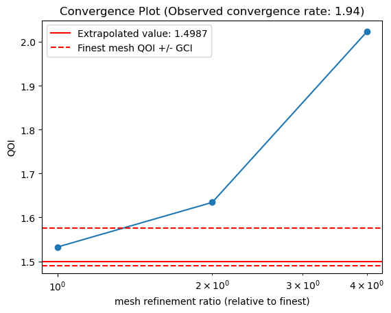

```python
dim=3
element_counts = [64000, 8000, 1000]
qoi_values = [1.532623,1.634262,2.02314]
ooc, re, gci = calcverif_tool.analyze_by_n_elems(element_counts,dim,qoi_values,formal_order_conv = 2.0)
print(f"OOC = {ooc}, extrapolated soln = {re}, GCI = {gci}")
fig, ax = calcverif_tool.plot()
```

### Oscillatory convergence

The convergence is monotonic is all the above examples. If instead there is oscillatory convergence with $N=3$, the user is prompted to repeat with more meshes:

```python
h_values = [0.1, 0.2, 0.4]
qoi_values = [1, 0.9, 1.5]  # oscillatory
ooc, re, gci = calcverif_tool.analyze(h_values,qoi_values,formal_order_conv = 1.0)
```

```
QOI values oscillatory - cannot compute metrics when N=3. Repeat with N>3 meshes.
```

Assume a new simulation was performed with a coarser mesh. Calling again, now with $N=4$, allows the least squares method to be used:

```
Method: least squares, as N>3 and QOI on finest three meshes is converging but oscillatory
Absolute GCI not relative GCI
Optimization terminated successfully.
         Current function value: 0.016183
         Iterations: 19
         Function evaluations: 88
         Gradient evaluations: 22
Note: OOC 2.6712 >= formal order - using formal order for calculating GCI
OOC = 2.6712076070623936, extrapolated soln = 0.9106416627435565, GCI = 0.09999999999999998
```

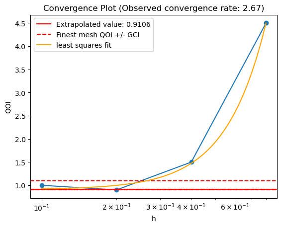

```python
h_values = [0.1, 0.2, 0.4, 0.8]
qoi_values = [1, 0.9, 1.5, 4.5]  # oscillatory on first three but N>3
ooc, re, gci = calcverif_tool.analyze(h_values,qoi_values,formal_order_conv = 2.0)
print(f"OOC = {ooc}, extrapolated soln = {re}, GCI = {gci}")
fig, ax = calcverif_tool.plot()
```

## Number of meshes $N>3$, monotonic convergence

When $N>3$ and the convergence is monotonic on the first triplet, OOC, $q_\textrm{RE}$ and GCI are computed using that triplet. Results for other triplets are provided, when computable, so they can be compared to the final values.

```
Method: analyzing each triplet, as N>3 and QOI on finest
three meshes is monotonically converging
Absolute GCIs not relative GCIs
Note: OOC 3.0000 >= formal order - using formal order for calculating RE and GCI
  triplet             convergence       OOC    RE       GCI
0   0,1,2  converging (monotonic)       3.0   1.5  0.004063
1   1,2,3  converging (monotonic)       3.0   1.5  0.063477
2   2,3,4  converging (monotonic)  2.756061   1.5      0.26
3   3,4,5               diverging      None  None      None

Final values:
OOC = 2.999999999999998, extrapolated soln = 1.5, GCI = 0.004062500000000002
```

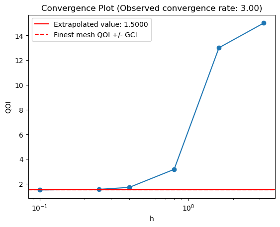

```python
h_values = [0.1, 0.25, 0.4, 0.8, 1.6, 3.2]                  # r not constant, due to 0.25
qoi_values = [1.50325,1.55078125,1.708,3.164,13,15]        # qoi = 1.5 + 3.25*h^3, except last two.
ooc, re, gci = calcverif_tool.analyze(h_values,qoi_values,formal_order_conv = 3.0)
print(f"\nFinal values:\nOOC = {ooc}, extrapolated soln = {re}, GCI = {gci}")
fig, ax = calcverif_tool.plot()
```

## Fluid flow in the inferior vena cava

Next, we demonstrate use of the tool with actual simulation results. In Craven, 2018, a computational fluid dynamics model was developed to characterize the steady-state flow field in the inferior vena cava (IVC). IVC filters are implanted to capture blood clots from deep vein thrombosis for prevention of recurrent pulmonary embolism. The open source OpenFOAM solver was used with a second-order accurate finite volume method. A mesh convergence study was performed using eight computational meshes ranging from 800,000 to 100 million elements. Using the results of that study, calculation verification metrics are computed below for two quantities of interest: the maximum velocity magnitude and volume-averaged helicity. Helicity is a derived quantity that characterizes the magnitude of swirl and mixing in the flow, and is defined as $\int_{\Omega}\mathbf{u} \cdot \left(\boldsymbol{\nabla} \times \mathbf{u}\right)\,\mathrm{d}V$. The following figure plots the three dimensional geometry (inset), cross-sectional regions of four sample meshes, and helicity on those regions (reproduced from Craven, 2018 with permission).

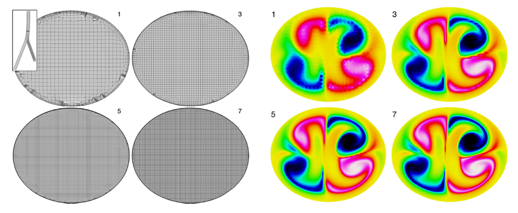

The meshes are unstructured but uniformly refined, and characterized by number of elements, so `analyze_by_n_elems` is called. While the numerical scheme is formally second-order accurate for the computed quantities of velocity and pressure, the theoretical rate of convergence for the location-dependent maximum velocity and the helicity QOIs is unclear. Therefore, the optional theoretical rate parameter is not passed in.

```
Max velocity results
====================
Method: analyzing each triplet, as N>3 and QOI on finest
three meshes is monotonically converging
Absolute GCIs not relative GCIs
  triplet             convergence       OOC        RE       GCI
0   0,1,2  converging (monotonic)  3.010971  0.252429  0.000297
1   1,2,3  converging (monotonic)  2.779564  0.252452  0.000667
2   2,3,4  converging (monotonic)  2.642296  0.252482  0.001356
3   3,4,5  converging (monotonic)  2.439694  0.252575  0.002774
4   4,5,6  converging (monotonic)  1.426014  0.254102  0.009456
5   5,6,7  converging (monotonic)  2.403948  0.252022  0.006907

Final values:
OOC = 3.0109708949395526, extrapolated soln = 0.2524291457331256, GCI = 0.00029743719937682837
```

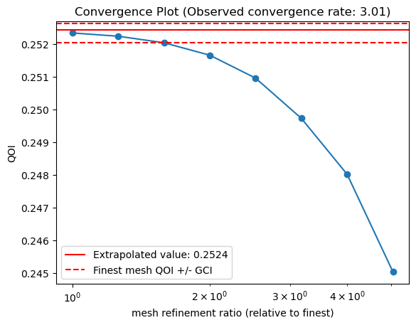

```
Helicity results
================
Method: analyzing each triplet, as N>3 and QOI on finest
three meshes is monotonically converging
Absolute GCIs not relative GCIs
  triplet             convergence       OOC        RE       GCI
0   0,1,2  converging (monotonic)  2.248534  0.458387  0.008691
1   1,2,3  converging (monotonic)  2.130507  0.458734  0.015672
2   2,3,4  converging (monotonic)  1.922291  0.459908  0.029154
3   3,4,5  converging (monotonic)  1.749775   0.46176  0.051001
4   4,5,6  converging (monotonic)  1.510509  0.466674  0.091153
5   5,6,7  converging (monotonic)  1.225823  0.478547  0.164842

Final values:
OOC = 2.248534454541711, extrapolated soln = 0.4583871099862752, GCI = 0.008691329958825605
```

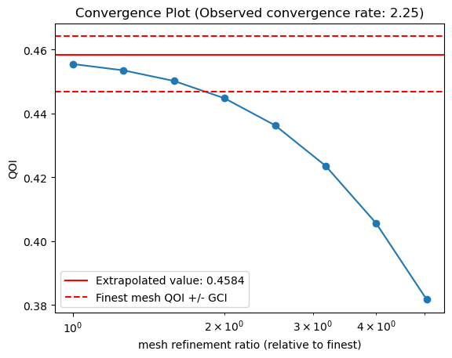

```
(<Figure size 640x480 with 1 Axes>,
 <Axes: title={'center': 'Convergence Plot (Observed convergence rate: 2.25)'}, xlabel='mesh refinement ratio (relative to finest)', ylabel='QOI'>)
```

```python
from calcverif import CalculationVerificationTool
import numpy as np
calcverif_tool = CalculationVerificationTool()

element_counts =   1e6*np.array([102.5,   51.16,   25.59,   12.8,    6.4,     3.2,     1.6,     0.8])
max_velocity   =       np.array([0.25233, 0.25223, 0.25203, 0.25165, 0.25095, 0.24972, 0.24801, 0.24503])
helicity       =       np.array([0.45549, 0.45351, 0.45019, 0.44476, 0.43629, 0.42360, 0.40561, 0.38173])

print("\nMax velocity results\n====================")
ooc, re, gci = calcverif_tool.analyze_by_n_elems(element_counts,3, max_velocity)
print(f"\nFinal values:\nOOC = {ooc}, extrapolated soln = {re}, GCI = {gci}")
calcverif_tool.plot()

print("\nHelicity results\n================")
ooc, re, gci = calcverif_tool.analyze_by_n_elems(element_counts,3, helicity)
print(f"\nFinal values:\nOOC = {ooc}, extrapolated soln = {re}, GCI = {gci}")
calcverif_tool.plot()

## Note: to save plots could do the following
#from matplotlib import pyplot as plt
#publication_style = {
#    'figure.figsize': (7.1, 5.0),
#    'font.size': 14,
#    'axes.titlesize': 14,
#    'axes.labelsize': 14,
#    'xtick.labelsize': 14,
#    'ytick.labelsize': 14,
#    'legend.fontsize': 14,
#    'lines.linewidth': 1.8,
#    'lines.markersize': 6,
#    'pdf.fonttype': 42,
#    'ps.fonttype': 42,
#}
#with plt.rc_context(publication_style):
#    fig, ax = calcverif_tool.plot()
#    fig.savefig('helicity_convergence.pdf', bbox_inches='tight')
#    plt.show()
```

Note the results above differ slightly from the calculation verification results provided in Craven, 2018 for two reasons: (i) Craven, 2018 used a different approach to computing GCI than implemented here; and (ii) here we used the QOI values reported in the publication which are provided to five decimal places. The calculation verification performed in the publication used QOI values to machine precision and it is important to be aware that this can have a noticeable difference on computed OOC, Richardson extrapolated value and GCI.

For example, consider the first triplet for maximum velocity, $[0.25233, 0.25223, 0.25203]$. Since these were provided to five decimal places in the publication, the actual value, pre-rounding, could be $\pm 5\times 10^{-6}$ for each. Below we re-calculate the metrics using $\pm 5\times 10^{-6}$ perturbations of the three maximum velocity values ($2^3$ combinations in total), and report the minimum and maximum values of each metric.

```python
import itertools

# initiating the class with the suppress_output flag will stop the method used being printed,
# useful here we are doing a simple Monte Carlo calculation.
calcverif_tool = CalculationVerificationTool(suppress_output = True)

element_counts =   1e6*np.array([102.5,   51.16,   25.59])
max_velocity_in_paper = np.array([0.25233, 0.25223, 0.25203])

ooc_store = []
re_store = []
gci_store = []

for signs in itertools.product([-1, 1], repeat=3):
    max_velocity_perturbed = max_velocity_in_paper + 0.000005*np.array(signs)
    ooc, re, gci = calcverif_tool.analyze_by_n_elems(element_counts,3, max_velocity_perturbed)
    ooc_store.append(ooc)
    re_store.append(re)
    gci_store.append(gci)
print(f"OOC range: [{np.min(np.array(ooc_store))},{np.max(np.array(ooc_store))}]")
print(f"RE range: [{np.min(np.array(re_store))},{np.max(np.array(re_store))}]")
print(f"GCI range: [{np.min(np.array(gci_store))},{np.max(np.array(gci_store))}]")
```

```
OOC range: [2.376882293264183,3.677751941307973]
RE range: [0.2523919599669619,0.25248481487644814]
GCI range: [0.00020087990088561418,0.0004494446293445395]
```

This is an eye-openingly wide range, especially for the observed order of convergence from 2.4 to 3.7, that are all consistent with the rounded values reported in the publication. This demonstrates how important it is to avoid rounding before running the calculation verification analysis.

# References

- ASME, V&V20: Standard for Verification and Validation in Computational Fluid Dynamics and Heat Transfer, 2018
- B. Craven, K. Aycock, K. Manning, Steady Flow in a Patient-Averaged Inferior Vena Cava: Part II—Computational Fluid Dynamics Verification and Validation, Cardiovascular Engineering and Technology, 2018
- FDA, Assessing the Credibility of Computational Modeling and Simulation in Medical Device Regulatory Submissions, 2023
- W. Oberkampf and C. Roy, Verification and Validation in Scientific Computing, 2025
- P. Roache, Fundamentals of Verification and Validation, 2009